# The Case for Reproducible Research

Institut für Organisation und Globale Managementstudien, JKU Linz

## Today's Agenda

- Reproducible Research
- markdown
- knitr
- R Markdown Example
- Assignments

## Acknowledgements

This class and many slides were inspired by:

**Brian Caffo, Jeff Leek, and Roger Peng**  
Department of Biostatistics  
Johns Hopkins Bloomberg School of Public Health

and the

[Coursera Data Science Specialization Program](https://www.coursera.org/specialization/jhudatascience/1?utm_medium=courseDescripTop)

## Reinhart & Rogoff (2010)

### Example of an error with consequences

## Seminal Paper

[figure not shown]

Reinhart, Carmen M.; Rogoff, Kenneth S. (2010). "Growth in a Time of Debt".  
American Economic Review 100 (2): 573–78.

## The Claim

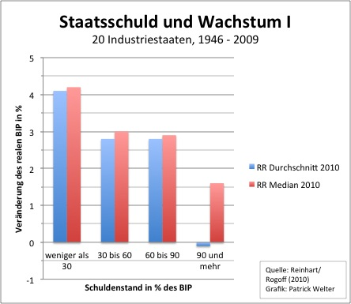

The paper argues that when "gross external debt reaches 60 percent of GDP",a country' annual growth declined by two percent, and"for levels of external debt in excess of 90 percent" GDP growth was "roughly cut in half."

## Political Impact

Appearing in the aftermath of the financial crisis of 2007–2008, the paper provided support for pro-austerity policies.

Politicians, commentators, and activists widely cited the paper in political debates over the effectiveness of austerity in fiscal policy for debt-burdened economies.

## Replication Study

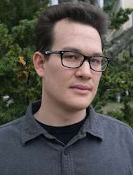

Thomas Herndon was a Ph.D. student at the University of Massachusetts Amherst.

His class assignment - pick an economics paper and see if you can replicate the results.

## The Error

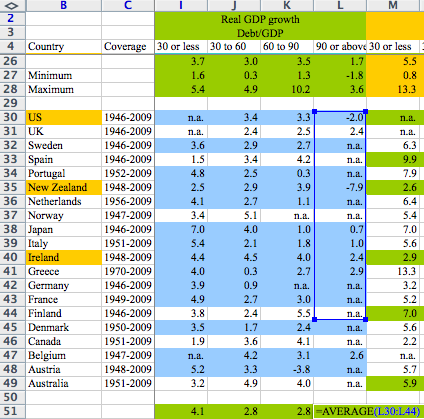

## Difference in Results

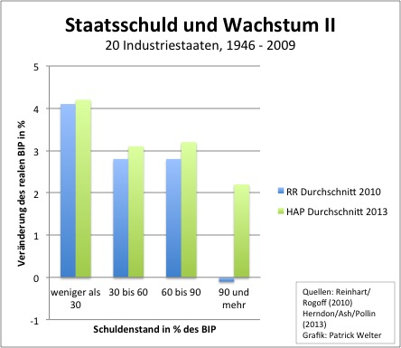

## Conclusions

- Do replication studies — you might get famous!
- Don't use Excel ;-)
- Publish your data and analysis tools together with the paper

## Reproducible Research

## Replication and Reproducibility

**Replication is the gold standard**

- New investigators, data, analytic methods, laboratories, instruments, etc.
- Focuses on the validity of the scientific claim
- "Is this claim true?"
- The ultimate standard for strengthening scientific evidence
- Particularly important in studies that can impact broad policy orregulatory decisions

## Replication and Reproducibility

**Reproducibility**

- Focuses on the validity of the data analysis
- "Can we trust this analysis?"
- Arguably a minimum standard for any scientific study
- New investigators, same data, same methods
- Important when replication is impossible

## What is Reproducible Research?

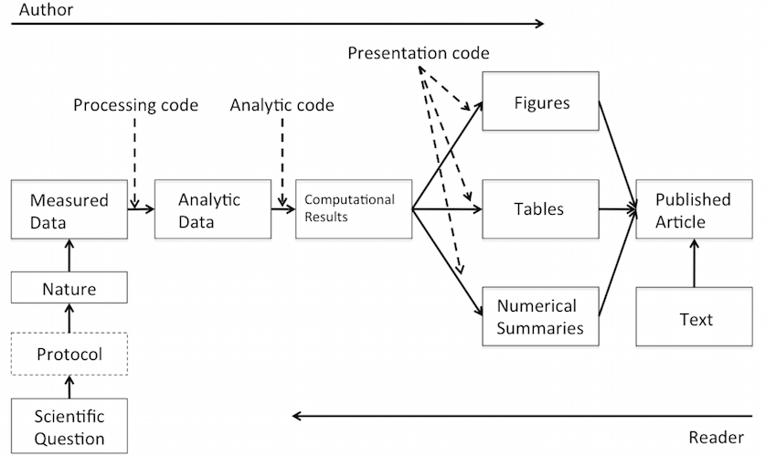

## What is Reproducible Research?

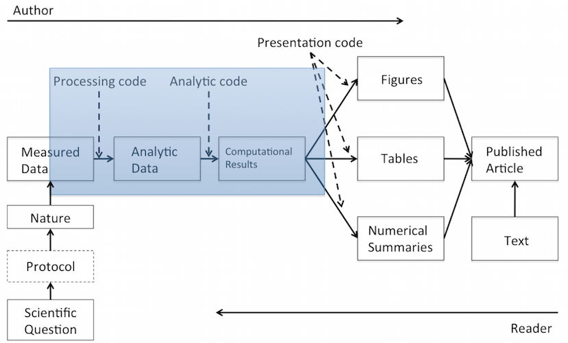

## What Problem Does Reproducibility Solve?

**What we get**

- Transparency
- Data Availability
- Software / Methods Availability
- Improved Transfer of Knowledge

## What Problem Does Reproducibility Solve?

**What we get**

- Transparency
- Data Availability
- Software / Methods Availability
- Improved Transfer of Knowledge

**What we do NOT get**

- Validity / Correctness of the analysis

An analysis can be reproducible and still be wrong

## Reproducible Research in Practice

## NASA Earth Exchange

[figure not shown]

[figure not shown]

## Reproducibility in Management Research

[figure not shown]

## Reproducibility in Cancer Research

**Great (and quite serious) case study:**

[The Importance of Reproducible Research in High-Throughput Biology](https://www.youtube.com/watch?v=7gYIs7uYbMo)

Keith A. Baggerly, MD Anderson Cancer Center

## More Information on Reproducible Research

Stodden, Leisch, Peng. 2014.  
[Implementing Reproducible Research](http://www.crcpress.com/product/isbn/9781466561595).  
Chapman and Hall/CRC.

Gandrud, Christopher. 2013.  
[Reproducible Research with R and R Studio](http://www.crcpress.com/product/isbn/9781466572843).  
Chapman and Hall/CRC.

Xie, Yihui. 2013.  
[Dynamic Documents with R and knitr](http://www.crcpress.com/product/isbn/9781482203530).  
Chapman and Hall/CRC.